# Naive Bayes

Dhrubasattwata Roy Choudhury

## Naive Bayes

Naive Bayes is a Supervised Machine Learning algorithm based on the Bayes Theorem that is used to solve classification problems by following a probabilistic approach. It is based on the idea that the predictor variables in a Machine Learning model are independent of each other. Meaning that the outcome of a model depends on a set of independent variables that have nothing to do with each other.

In real-world problems, predictor variables aren’t always independent of each other, there are always some correlations between them. Since Naive Bayes considers each predictor variable to be independent of any other variable in the model, it is called ‘Naive’.

Now let’s understand the logic behind the Naive Bayes algorithm.

The principle behind Naive Bayes is the Bayes theorem also known as the Bayes Rule. The Bayes theorem is used to calculate the conditional probability, which is nothing but the probability of an event occurring based on information about the events in the past.Therefore, the Bayes theorem can be summed up as:  
Posterior=(Likelihood).(Proposition prior probability)/Evidence prior probability

```r
# Import the packages
library(tidyverse)
```

```r
library(ggplot2)
library(caret)
library(caretEnsemble)
library(Amelia)
library(mice)
library(GGally)
library(rpart)
library(randomForest)
```

### Datasets

```r
data<- read.csv("C:/Users/Dhruba/Documents/R/data/diabetes.csv")
```

Before we study the data set let’s convert the output variable (‘Outcome’) into a categorical variable. This is necessary because our output will be in the form of 2 classes, True or False. Where true will denote that a patient has diabetes and false denotes that a person is diabetes free

```r
#Setting outcome variables as categorical
data$Outcome <- factor(data$Outcome, levels = c(0,1), labels = c("False", "True"))
```

### Data Exploration

```r
str(data)
```

```
## 'data.frame':    768 obs. of  9 variables:
##  $ Pregnancies             : int  6 1 8 1 0 5 3 10 2 8 ...
##  $ Glucose                 : int  148 85 183 89 137 116 78 115 197 125 ...
##  $ BloodPressure           : int  72 66 64 66 40 74 50 0 70 96 ...
##  $ SkinThickness           : int  35 29 0 23 35 0 32 0 45 0 ...
##  $ Insulin                 : int  0 0 0 94 168 0 88 0 543 0 ...
##  $ BMI                     : num  33.6 26.6 23.3 28.1 43.1 25.6 31 35.3 30.5 0 ...
##  $ DiabetesPedigreeFunction: num  0.627 0.351 0.672 0.167 2.288 ...
##  $ Age                     : int  50 31 32 21 33 30 26 29 53 54 ...
##  $ Outcome                 : Factor w/ 2 levels "False","True": 2 1 2 1 2 1 2 1 2 2 ...
```

```r
head(data)
```

```
##   Pregnancies Glucose BloodPressure SkinThickness Insulin  BMI
## 1           6     148            72            35       0 33.6
## 2           1      85            66            29       0 26.6
## 3           8     183            64             0       0 23.3
## 4           1      89            66            23      94 28.1
## 5           0     137            40            35     168 43.1
## 6           5     116            74             0       0 25.6
##   DiabetesPedigreeFunction Age Outcome
## 1                    0.627  50    True
## 2                    0.351  31   False
## 3                    0.672  32    True
## 4                    0.167  21   False
## 5                    2.288  33    True
## 6                    0.201  30   False
```

```r
#describe(data)
```

### Data Cleaning

```r
#Convert '0' values into NA
data[, 2:7][data[, 2:7] == 0] <- NA
```

### Visualize

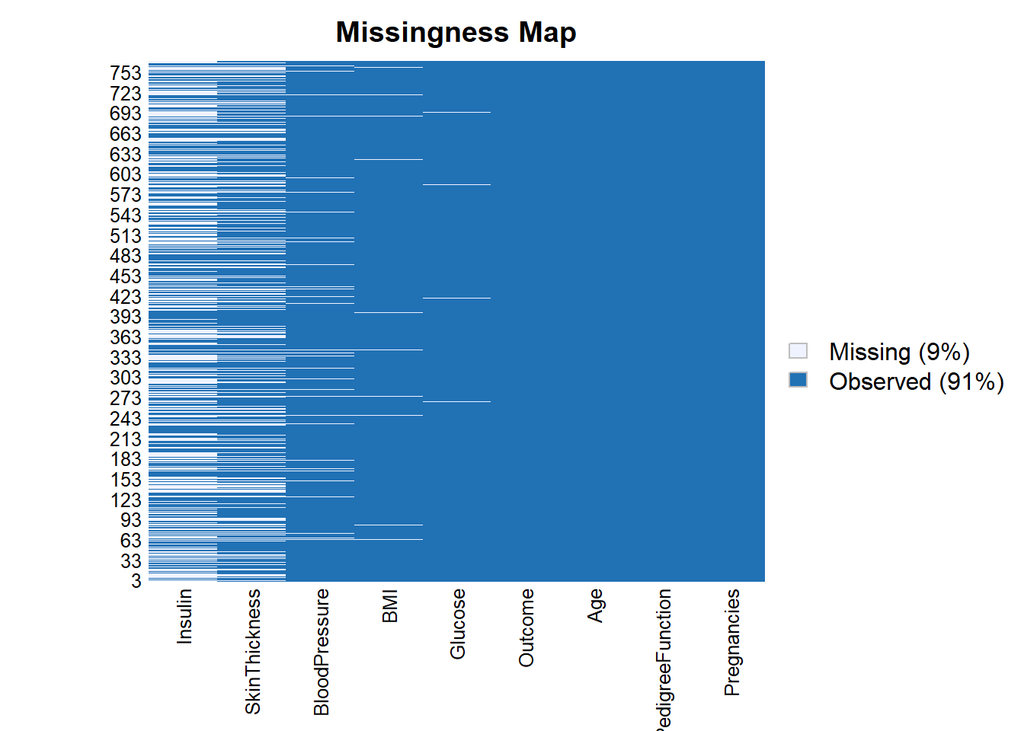

```r
#visualize the missing data
missmap(data)
```

The above illustrations show that our data set has plenty missing values and removing all of them will leave us with an even smaller data set, therefore, we can perform imputations by using the mice package in R.

```r
#Use mice package to predict missing values
mice_mod <- mice(data[, c("Glucose","BloodPressure","SkinThickness","Insulin","BMI")], method='rf')
mice_complete <- complete(mice_mod)

#Transfer the predicted missing values into the main data set
data$Glucose <- mice_complete$Glucose
data$BloodPressure <- mice_complete$BloodPressure
data$SkinThickness <- mice_complete$SkinThickness
data$Insulin<- mice_complete$Insulin
data$BMI <- mice_complete$BMI
```

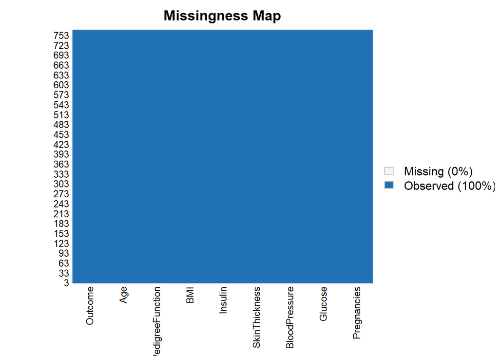

```r
#visualize the missing data
missmap(data)
```

### Exploratory Data Analysis

Now let’s perform a couple of visualizations to take a better look at each variable, this stage is essential to understand the significance of each predictor variable.

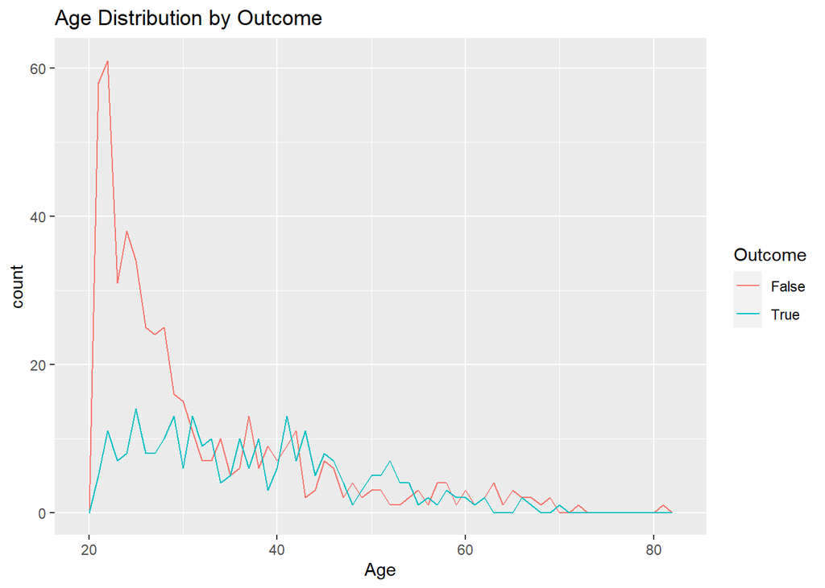

```r
#Data Visualization
#Visual 1
ggplot(data, aes(Age, colour = Outcome)) +
geom_freqpoly(binwidth = 1) + labs(title="Age Distribution by Outcome")
```

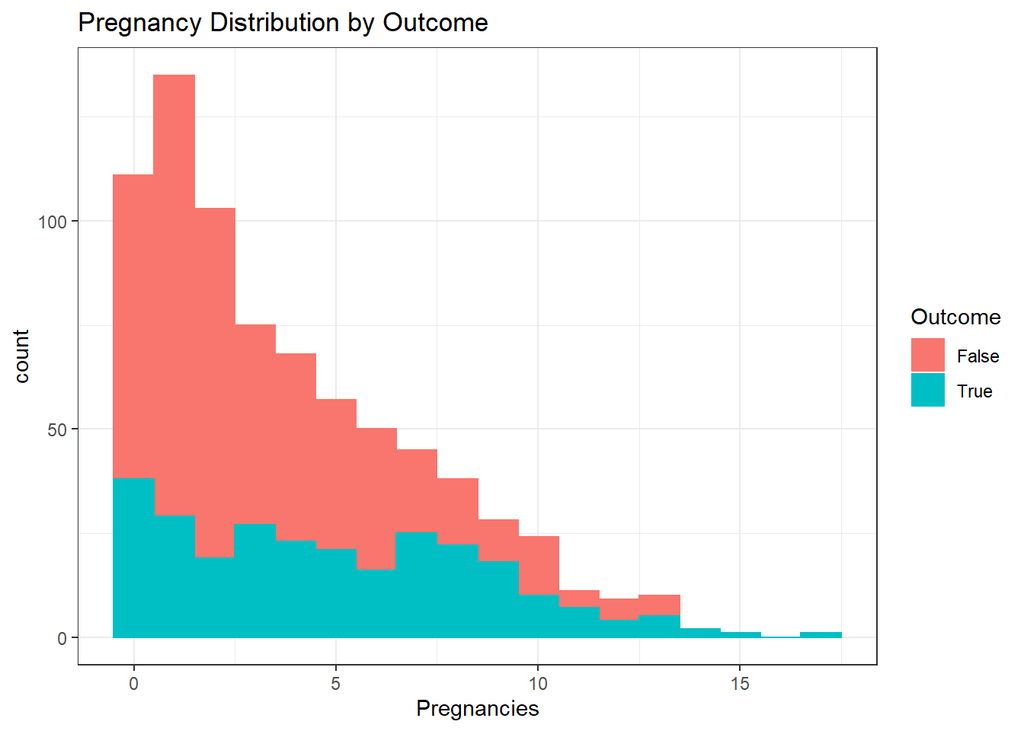

```r
#visual 2
c <- ggplot(data, aes(x=Pregnancies, fill=Outcome, color=Outcome)) +
geom_histogram(binwidth = 1) + labs(title="Pregnancy Distribution by Outcome")
c + theme_bw()
```

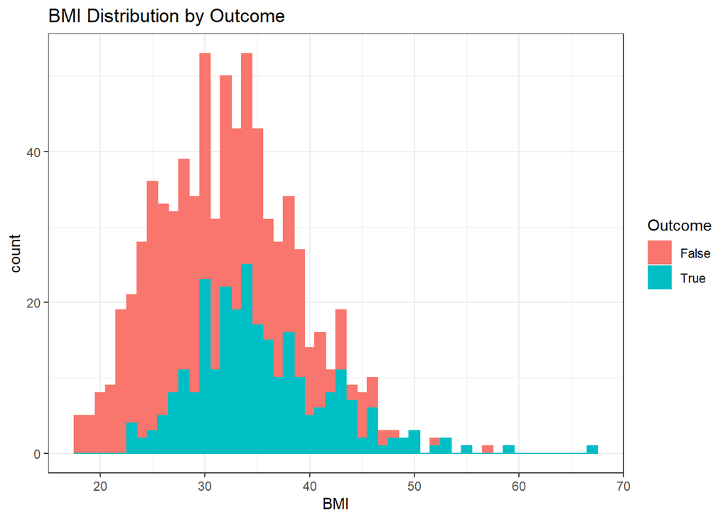

```r
#visual 3
P <- ggplot(data, aes(x=BMI, fill=Outcome, color=Outcome)) +
geom_histogram(binwidth = 1) + labs(title="BMI Distribution by Outcome")
P + theme_bw()
```

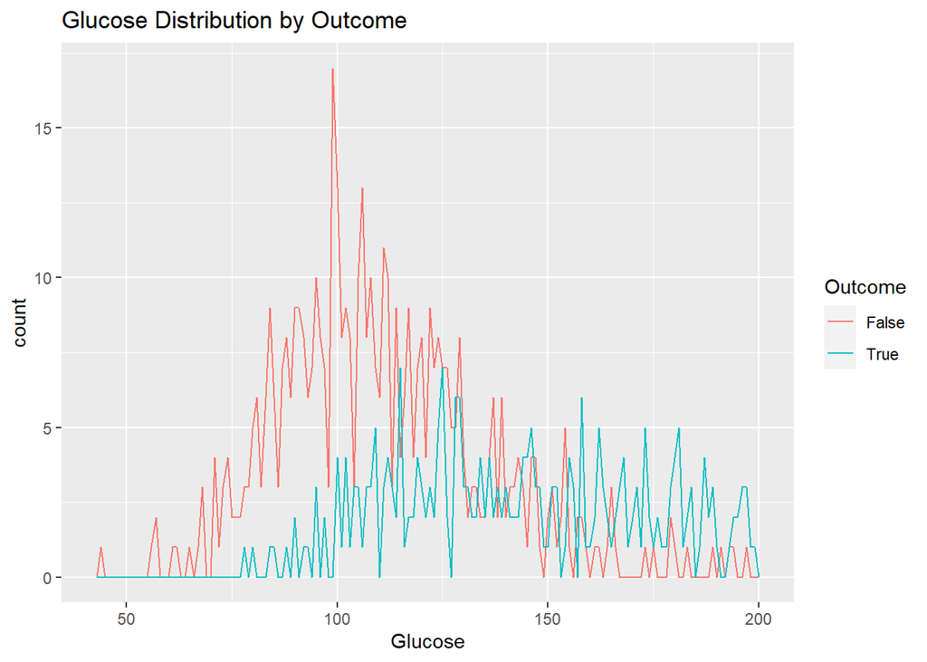

```r
#visual 4
ggplot(data, aes(Glucose, colour = Outcome)) +
geom_freqpoly(binwidth = 1) + labs(title="Glucose Distribution by Outcome")
```

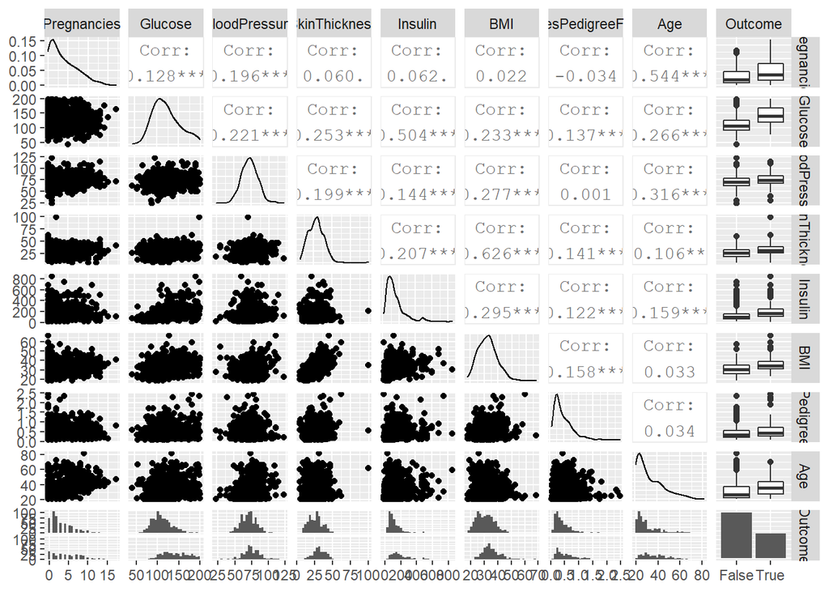

```r
#visual 5
ggpairs(data)
```

### Data Modelling

This stage begins with a process called Data Splicing, wherein the data set is split into two parts:

1. Training set: This part of the data set is used to build and train the Machine Learning model.
2. Testing set: This part of the data set is used to evaluate the efficiency of the model.

```r
#Building a model
#split data into training and test data sets
indxTrain <- createDataPartition(y = data$Outcome,p = 0.75,list = FALSE)
training <- data[indxTrain,]
testing <- data[-indxTrain,] #Check dimensions of the split > prop.table(table(data$Outcome)) * 100

prop.table(table(training$Outcome)) * 100
```

```
##
##    False     True
## 65.10417 34.89583
```

```r
prop.table(table(testing$Outcome)) * 100
```

```
##
##    False     True
## 65.10417 34.89583
```

For comparing the outcome of the training and testing phase let’s create separate variables that store the value of the response variable:

```r
#create objects x which holds the predictor variables and y which holds the response variables
x = training[,-9]
y = training$Outcome
```

Now it’s time to load the e1071 package that holds the Naive Bayes function. This is an in-built function provided by R.

```r
library(e1071)
library(klaR)
model = suppressWarnings(train(x,y,'nb',trControl=trainControl(method='cv',number=10)))
model
```

```
## Naive Bayes
##
## 576 samples
##   8 predictor
##   2 classes: 'False', 'True'
##
## No pre-processing
## Resampling: Cross-Validated (10 fold)
## Summary of sample sizes: 519, 518, 519, 517, 518, 519, ...
## Resampling results across tuning parameters:
##
##   usekernel  Accuracy   Kappa
##   FALSE      0.7533703  0.4539184
##    TRUE      0.7602408  0.4770693
##
## Tuning parameter 'fL' was held constant at a value of 0
## Tuning
##  parameter 'adjust' was held constant at a value of 1
## Accuracy was used to select the optimal model using the largest value.
## The final values used for the model were fL = 0, usekernel = TRUE and adjust
##  = 1.
```

We thus created a predictive model by using the Naive Bayes Classifier.

### Model Evaluation

To check the efficiency of the model, we are now going to run the testing data set on the model, after which we will evaluate the accuracy of the model by using a Confusion matrix.

```r
#Model Evaluation
#Predict testing set
Predict <- suppressWarnings(predict(model,newdata = testing )) #Get the confusion matrix to see accuracy value and other parameter values
confusionMatrix(Predict, testing$Outcome )
```

```
## Confusion Matrix and Statistics
##
##           Reference
## Prediction False True
##      False   102   26
##      True     23   41
##
##                Accuracy : 0.7448
##                  95% CI : (0.677, 0.8048)
##     No Information Rate : 0.651
##     P-Value [Acc > NIR] : 0.003401
##
##                   Kappa : 0.4324
##
##  Mcnemar's Test P-Value : 0.775097
##
##             Sensitivity : 0.8160
##             Specificity : 0.6119
##          Pos Pred Value : 0.7969
##          Neg Pred Value : 0.6406
##              Prevalence : 0.6510
##          Detection Rate : 0.5312
##    Detection Prevalence : 0.6667
##       Balanced Accuracy : 0.7140
##
##        'Positive' Class : False
##
```

To summaries the demo, let’s draw a plot that shows how each predictor variable is independently responsible for predicting the outcome.

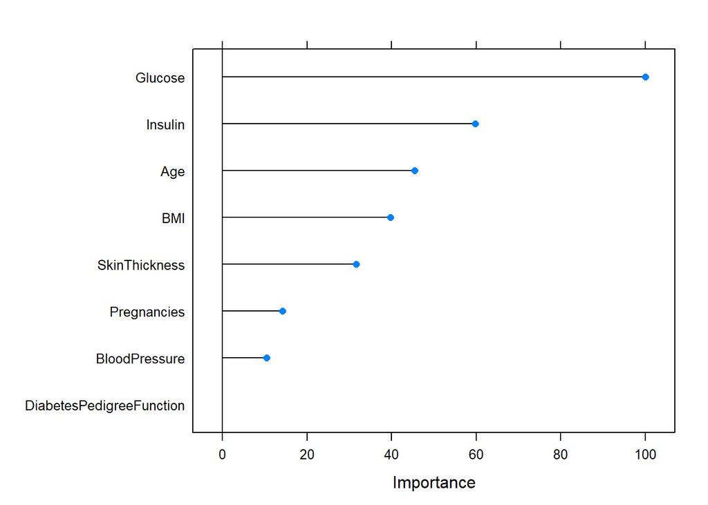

```r
#Plot Variable performance
X <- varImp(model)
plot(X)
```